# index.Rmd

# Variable Comparison Chart

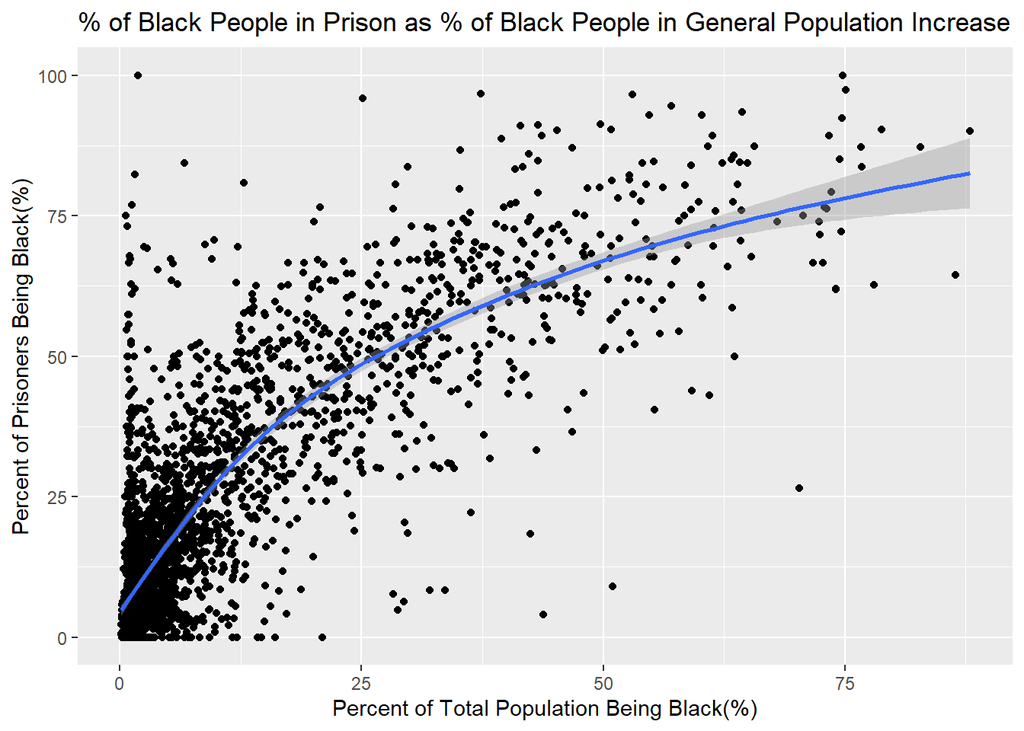

This graph plots the percent of the total population being black with the percent of prisoners being black. Obviously when the percent of the total population being Black is close to 0, the percent of prisoners being Black is also nearly 0, but the interesting info comes in between the extremes. When the population is 75% Black, there is not a higher proportion of Black people incarcerated, but when the population is 50% Black, they make up about 65% of the prison population. The difference is even higher when Black people are only 25% of the population, where they still account for about 50% of the prison population. It is impossible to say exactly why this is, but one theory is that the higher the percentage of non-Black people in a population, the more the systematic-racism manifests itself.

# Map

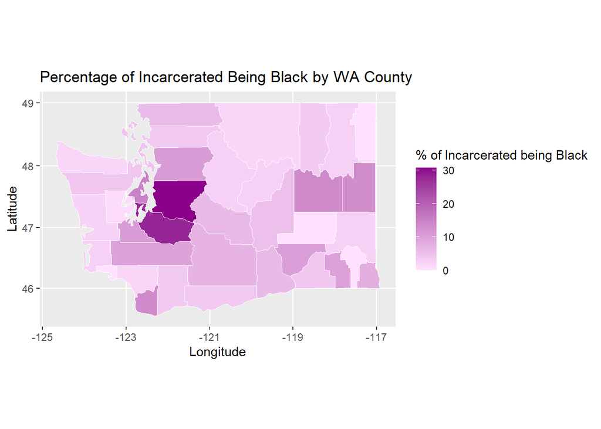

This is a map of Washington where each county is colored differently based on the % of those incarcerated being Black. Counties like King County that are darker purple in color have a higher percentage of Black people incarcerated. This data could be explained because in some counties (like those in Eastern Washington), there may be fewer Black people in the population in general, which translates to a lower Black population in prisons.